# Predicting Correct Exercise Form from Dumbbell Curl Data

Jose Albornoz

Sunday, March 22, 2015

### 1.- Executive Summary

In this document we will examine the use of machine learning techniques to distinguish between bad and good form when executing dumbbell biceps curls using data acquired through sensors in the users’ glove, armband, lumbar belt and dumbbell. The algorithm must distinguish between 5 possible ways of performing the exercise, one corresponding to the correct form and four other incorrect way; the data set thus describes activities that correspond to the following classes:

- Class A: Correct form
- Class B: Throwing the elbows to the front
- Class C: Lifting the dumbbell only halfway
- Class D: Lowering the dumbbell only halfway
- Class E: Throwing the hips to the front.

The sensors used in this study measure pitch, roll and yaw angles as well as x-y-z components for acceleration, gyroscope and magnetometer data. The reference coordinate system used can be seen in Fig. 1 of [“Qualitative Activity Recognition of Weight Lifting Exercises”](http://groupware.les.inf.puc-rio.br/work.jsf?p1=11201) by Velloso et al. which is reproduced below. Note the orientation of the cartesian coordinate system associated to the sensors: we will take advantage of this orientation as well as of the mechanics of the dumbbell curl for feature selection purposes.

[figure not shown]

### 2.- Preliminary Cleansing

We will first load some required libraries and setting the seed for random number generation.

```r
library(caret)
```

```r
library(ggplot2)
library(corrplot)
library(reshape)
set.seed(1234)
```

We read the data sets into memory,

```r
training0 <- read.csv("pml-training.csv")
testing0 <- read.csv("pml-testing.csv")
```

And print the dimensions of the training and testing sets

```r
dim(training0)
```

```
## [1] 19622   160
```

```r
dim(testing0)
```

```
## [1]  20 160
```

We notice that the original training set contains 160 columns. In order to get an idea of the particular meaning of each variable we will print column names

```r
names(training0)
```

```
##   [1] "X"                        "user_name"
##   [3] "raw_timestamp_part_1"     "raw_timestamp_part_2"
##   [5] "cvtd_timestamp"           "new_window"
##   [7] "num_window"               "roll_belt"
##   [9] "pitch_belt"               "yaw_belt"
##  [11] "total_accel_belt"         "kurtosis_roll_belt"
##  [13] "kurtosis_picth_belt"      "kurtosis_yaw_belt"
##  [15] "skewness_roll_belt"       "skewness_roll_belt.1"
##  [17] "skewness_yaw_belt"        "max_roll_belt"
##  [19] "max_picth_belt"           "max_yaw_belt"
##  [21] "min_roll_belt"            "min_pitch_belt"
##  [23] "min_yaw_belt"             "amplitude_roll_belt"
##  [25] "amplitude_pitch_belt"     "amplitude_yaw_belt"
##  [27] "var_total_accel_belt"     "avg_roll_belt"
##  [29] "stddev_roll_belt"         "var_roll_belt"
```

[output cut: 65 more lines]

Upon inspection of this list it can be appreciated that variable **classe** is the classification label for each type of activity, and that the first seven variables are not related to data generated by the sensors. We therefore expunge these first seven columns from the training and testing data sets.

```r
training1 <- training0[,-c(1:7)]
testing1 <- testing0[,-c(1:7)]
```

We now obtain a summary of the resulting data set

```r
summary(training1)
```

```
##    roll_belt        pitch_belt          yaw_belt       total_accel_belt
##  Min.   :-28.90   Min.   :-55.8000   Min.   :-180.00   Min.   : 0.00
##  1st Qu.:  1.10   1st Qu.:  1.7600   1st Qu.: -88.30   1st Qu.: 3.00
##  Median :113.00   Median :  5.2800   Median : -13.00   Median :17.00
##  Mean   : 64.41   Mean   :  0.3053   Mean   : -11.21   Mean   :11.31
##  3rd Qu.:123.00   3rd Qu.: 14.9000   3rd Qu.:  12.90   3rd Qu.:18.00
##  Max.   :162.00   Max.   : 60.3000   Max.   : 179.00   Max.   :29.00
##
##  kurtosis_roll_belt kurtosis_picth_belt kurtosis_yaw_belt
##           :19216             :19216            :19216
##  #DIV/0!  :   10    #DIV/0!  :   32     #DIV/0!:  406
##  -1.908453:    2    47.000000:    4
##  -0.016850:    1    -0.150950:    3
##  -0.021024:    1    -0.684748:    3
##  -0.025513:    1    -1.750749:    3
##  (Other)  :  391    (Other)  :  361
##  skewness_roll_belt skewness_roll_belt.1 skewness_yaw_belt
##           :19216             :19216             :19216
##  #DIV/0!  :    9    #DIV/0!  :   32      #DIV/0!:  406
##  0.000000 :    4    0.000000 :    4
##  0.422463 :    2    -2.156553:    3
##  -0.003095:    1    -3.072669:    3
##  -0.010002:    1    -6.324555:    3
##  (Other)  :  389    (Other)  :  361
##  max_roll_belt     max_picth_belt   max_yaw_belt   min_roll_belt
##  Min.   :-94.300   Min.   : 3.00          :19216   Min.   :-180.00
##  1st Qu.:-88.000   1st Qu.: 5.00   -1.1   :   30   1st Qu.: -88.40
##  Median : -5.100   Median :18.00   -1.4   :   29   Median :  -7.85
##  Mean   : -6.667   Mean   :12.92   -1.2   :   26   Mean   : -10.44
##  3rd Qu.: 18.500   3rd Qu.:19.00   -0.9   :   24   3rd Qu.:   9.05
##  Max.   :180.000   Max.   :30.00   -1.3   :   22   Max.   : 173.00
##  NA's   :19216     NA's   :19216   (Other):  275   NA's   :19216
##  min_pitch_belt   min_yaw_belt   amplitude_roll_belt amplitude_pitch_belt
##  Min.   : 0.00          :19216   Min.   :  0.000     Min.   : 0.000
##  1st Qu.: 3.00   -1.1   :   30   1st Qu.:  0.300     1st Qu.: 1.000
##  Median :16.00   -1.4   :   29   Median :  1.000     Median : 1.000
##  Mean   :10.76   -1.2   :   26   Mean   :  3.769     Mean   : 2.167
##  3rd Qu.:17.00   -0.9   :   24   3rd Qu.:  2.083     3rd Qu.: 2.000
##  Max.   :23.00   -1.3   :   22   Max.   :360.000     Max.   :12.000
##  NA's   :19216   (Other):  275   NA's   :19216       NA's   :19216
```

[output cut: 297 more lines]

```
##  Min.   : -8.0900   Min.   :-498.00   Min.   :-632.0   Min.   :-446.00
##  1st Qu.: -0.1800   1st Qu.:-178.00   1st Qu.:  57.0   1st Qu.:-182.00
##  Median :  0.0800   Median : -57.00   Median : 201.0   Median : -39.00
##  Mean   :  0.1512   Mean   : -61.65   Mean   : 163.7   Mean   : -55.29
##  3rd Qu.:  0.4900   3rd Qu.:  76.00   3rd Qu.: 312.0   3rd Qu.:  26.00
##  Max.   :231.0000   Max.   : 477.00   Max.   : 923.0   Max.   : 291.00
##
##  magnet_forearm_x  magnet_forearm_y magnet_forearm_z classe
##  Min.   :-1280.0   Min.   :-896.0   Min.   :-973.0   A:5580
##  1st Qu.: -616.0   1st Qu.:   2.0   1st Qu.: 191.0   B:3797
##  Median : -378.0   Median : 591.0   Median : 511.0   C:3422
##  Mean   : -312.6   Mean   : 380.1   Mean   : 393.6   D:3216
##  3rd Qu.:  -73.0   3rd Qu.: 737.0   3rd Qu.: 653.0   E:3607
##  Max.   :  672.0   Max.   :1480.0   Max.   :1090.0
##
```

We can observe that there are a number of columns that either contain either a large number of NAs or a large number of blank spaces; in both cases the number of rows containing such values is 19216, or 98% of the total number of rows in the data set. We can therefore discard the features that correspond to these columns. For this purpose we will define a couple of small functions to count the number of NAs and the number of blank spaces in a column

```r
# count NAs in a column
countNA <- function(X) {
  sum(is.na(X))
}

# count blank spaces in a columns
countSP <- function(X) {
  sum(X == "")
}
```

We expunge the columns with NAs or blank spaces from the data sets

```r
training2 <- training1[,which(sapply(training1, countNA) == 0)]
testing2 <- testing1[,which(sapply(training1, countNA) == 0)]

training3 <- training2[,which(sapply(training2, countSP) == 0)]
testing3 <- testing2[,which(sapply(training2, countSP) == 0)]
```

The number of features in the training set is now

```r
dim(training3)
```

```
## [1] 19622    53
```

We can eliminate a few more features from the data set by examining Fig. 1 reproduced above. First we note that the sensors register picth, roll and yaw; however the description of the movements involved in a dumbbell curl involve mostly pitch angles since they take place in the y-z plane. For this reason we can discard those features which are related to yaw or roll angles as well as those corresponding to acceleration or magnetometer components in the x-axis (for a description of picth, roll and yaw angles see [this link](http://en.wikipedia.org/wiki/Aircraft_principal_axes)).

```r
# physically relevant variables only
relVars <- grep("pitch?|?_y|?_z|classe", names(training3))
training4 <- training3[,relVars]
testing4 <- testing3[,relVars]
```

The dimension of the resulting cleansed training data set is now

```r
dim(training4)
```

```
## [1] 19622    29
```

In order to have an idea of the correlations between features we will plot them using package *Corrplot*

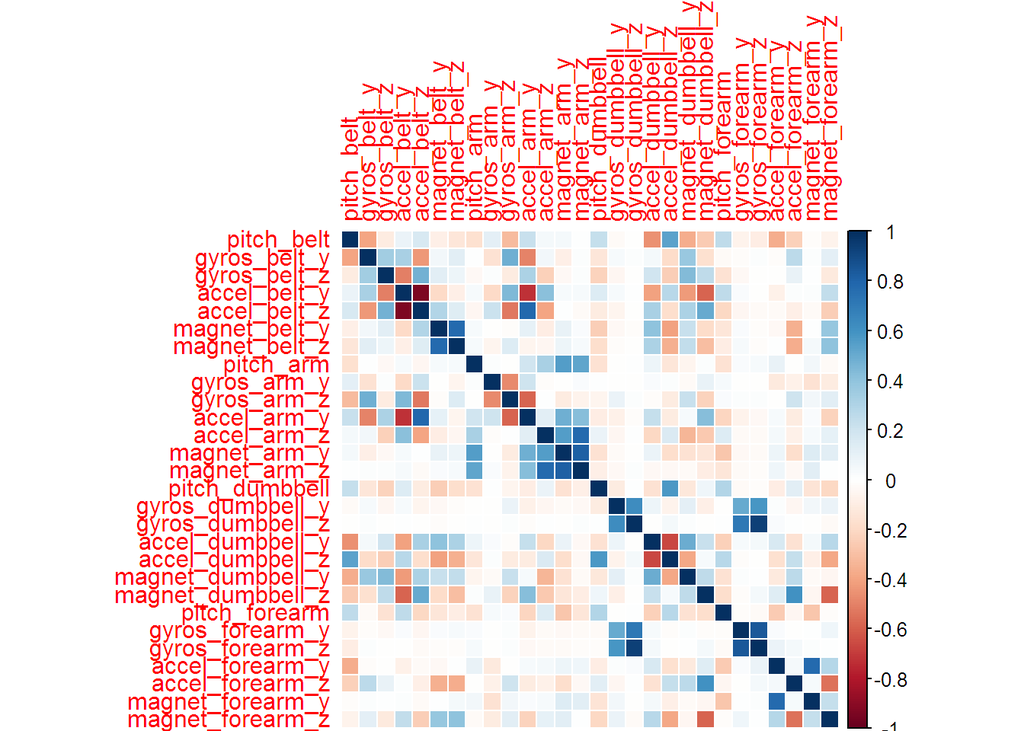

```r
correlation <- cor(training4[, -29])
corrplot(correlation, method = "color")
```

An examination of this plot reveals that in somer cases there is a strong correlation between features generated in the same sensor. For instance, it can be seen that **accel_arm_y** and **accel_arm_z** are strongly correalted with **magnet_arm_y** and **magnet_arm_z**. In another case there is strong correlation between particular features generated at different sensors, such as the one observed between **gyros_dumbbell_y**, **gyros_dumbbell_z** and **gyros_forearm_y**, **gyros_forearm_z**; this could be explained by the physical proximith between the glove and dumbbell sensors.

In order to verify that all the features indeed contribute to the variability of the outcome, we will now verify that none of the selected predictors has non-zero variance

```r
nzv <- nearZeroVar(training4, saveMetrics=TRUE)
nzv
```

```
##                   freqRatio percentUnique zeroVar   nzv
## pitch_belt         1.036082     9.3772296   FALSE FALSE
## gyros_belt_y       1.144000     0.3516461   FALSE FALSE
## gyros_belt_z       1.066214     0.8612782   FALSE FALSE
## accel_belt_y       1.113725     0.7287738   FALSE FALSE
## accel_belt_z       1.078767     1.5237998   FALSE FALSE
## magnet_belt_y      1.099688     1.5187035   FALSE FALSE
## magnet_belt_z      1.006369     2.3290184   FALSE FALSE
## pitch_arm         87.256410    15.7323412   FALSE FALSE
## gyros_arm_y        1.454369     1.9162165   FALSE FALSE
## gyros_arm_z        1.110687     1.2638875   FALSE FALSE
## accel_arm_y        1.140187     2.7367241   FALSE FALSE
## accel_arm_z        1.128000     4.0362858   FALSE FALSE
## magnet_arm_y       1.056818     4.4439914   FALSE FALSE
## magnet_arm_z       1.036364     6.4468454   FALSE FALSE
## pitch_dumbbell     2.277372    81.7449801   FALSE FALSE
## gyros_dumbbell_y   1.264957     1.4167771   FALSE FALSE
## gyros_dumbbell_z   1.060100     1.0498420   FALSE FALSE
## accel_dumbbell_y   1.053061     2.3748853   FALSE FALSE
## accel_dumbbell_z   1.133333     2.0894914   FALSE FALSE
## magnet_dumbbell_y  1.197740     4.3012945   FALSE FALSE
## magnet_dumbbell_z  1.020833     3.4451126   FALSE FALSE
## pitch_forearm     65.983051    14.8557741   FALSE FALSE
## gyros_forearm_y    1.036554     3.7763735   FALSE FALSE
## gyros_forearm_z    1.122917     1.5645704   FALSE FALSE
## accel_forearm_y    1.059406     5.1116094   FALSE FALSE
## accel_forearm_z    1.006250     2.9558659   FALSE FALSE
## magnet_forearm_y   1.246914     9.5403119   FALSE FALSE
## magnet_forearm_z   1.000000     8.5771073   FALSE FALSE
## classe             1.469581     0.0254816   FALSE FALSE
```

It can be seen that all of the predictors in the reduced training data set are relevant.

### 4.- Predictive Model

We will build our classification model by using a random forest. First we will split our original training set into two subsets, one to train our model and another to test it.

```r
inTrain <- createDataPartition(y=training4$classe, p=0.7, list=FALSE)
training <- training4[inTrain,]
testing <- training4[-inTrain,]
```

We will use k-fold cross-validation to determine how well the model will generalize to an independent data set; for reasons of efficiency we will use 5 folds.

```r
fitControl <- trainControl(method = "cv", number = 5, savePredictions = TRUE, allowParallel = TRUE)
```

We now proceed to train our model

```r
rfModelFit <- train(classe ~ ., data = training, method = "rf", trControl = fitControl)
rfModelFit
```

```
## Random Forest
##
## 13737 samples
##    28 predictor
##     5 classes: 'A', 'B', 'C', 'D', 'E'
##
## No pre-processing
## Resampling: Cross-Validated (5 fold)
##
## Summary of sample sizes: 10990, 10988, 10991, 10990, 10989
##
## Resampling results across tuning parameters:
##
##   mtry  Accuracy   Kappa      Accuracy SD  Kappa SD
##    2    0.9857318  0.9819457  0.002858910  0.003616820
##   15    0.9818740  0.9770669  0.003288092  0.004157158
##   28    0.9744486  0.9676760  0.002473882  0.003131624
##
## Accuracy was used to select the optimal model using  the largest value.
## The final value used for the model was mtry = 2.
```

We can see that across the 5-fold cross-validation the accuracy of our model is over 97%. We now test the model on the testing data obtained from the split of the original training data.

```r
prediction <- predict(rfModelFit, testing)
print(confusionMatrix(prediction, testing$classe))
```

```
## Confusion Matrix and Statistics
##
##           Reference
## Prediction    A    B    C    D    E
##          A 1673   13    0    0    0
##          B    1 1125   10    0    0
##          C    0    1 1014   24    3
##          D    0    0    2  939    1
##          E    0    0    0    1 1078
##
## Overall Statistics
##
##                Accuracy : 0.9905
##                  95% CI : (0.9877, 0.9928)
##     No Information Rate : 0.2845
##     P-Value [Acc > NIR] : < 2.2e-16
##
##                   Kappa : 0.988
##  Mcnemar's Test P-Value : NA
##
## Statistics by Class:
##
##                      Class: A Class: B Class: C Class: D Class: E
## Sensitivity            0.9994   0.9877   0.9883   0.9741   0.9963
## Specificity            0.9969   0.9977   0.9942   0.9994   0.9998
## Pos Pred Value         0.9923   0.9903   0.9731   0.9968   0.9991
## Neg Pred Value         0.9998   0.9971   0.9975   0.9949   0.9992
## Prevalence             0.2845   0.1935   0.1743   0.1638   0.1839
## Detection Rate         0.2843   0.1912   0.1723   0.1596   0.1832
## Detection Prevalence   0.2865   0.1930   0.1771   0.1601   0.1833
## Balanced Accuracy      0.9982   0.9927   0.9913   0.9867   0.9980
```

The accuracy of this model is over 99% in our testing data for the particular pseudo-random number generator seed used in this script. We can now obtain a prediction for the test data provided in the original data set

```r
predict(rfModelFit, testing4[,-29])
```

```
##  [1] B A B A A E D B A A B C B A E E A B B B
## Levels: A B C D E
```